# EAI Tutorial 2.2

## Recursive Vectors

We may wish to group these players by positions at which we’re likely to find them during the play. We may also want to include additional data, such as are name or wage, so we know how much a team will cost overall. Let’s consider two distinct (but legitimate) ways to organize these data.

### Lists

One may first consider grouping players by playing position. For example, left wingers and strikers are playing offensive and players playing centre back and goal keepers are in the rear. If we were to continue to group them by specialization, we may arrive at a data set which looks something like this:

```r
Players <- list(Offense = data.frame(Position = c('Striker', 'Left Winger'), Wage = c(2.1, 0.49)),
                Midfielders = data.frame(Position = c('Center', 'Right Midfielder'), Wage = c(2.18, 3.89)),
                Defense = data.frame(Position = c('Goal Keeper', 'Right Center Back'), Wage = c(0.99, 0.69)))

Players[1:2]
```

```
## $Offense
##      Position Wage
## 1     Striker 2.10
## 2 Left Winger 0.49
##
## $Midfielders
##           Position Wage
## 1           Center 2.18
## 2 Right Midfielder 3.89
```

Here, we use a **list** structure to organize the players list. As constructed, this list is an example of **non-rectangular data**. As a whole, the players list is not shaped like a rectangle, but rather, consists of sets of rectangular data (vectors, matrices, etc.), where each set is defined by the player’s position. Within a position trim, the player’s positions and wages are given in rectangular form since every value is defined by a row and column.

Unlike atomic vectors, the content of a list is not restricted to a single mode and can encompass any data type. For example, first element of a list can be a list, second a character vector, third a Boolean vector, and so.

```r
list1<- list(first = list(alpha = 1:5,
                          beta = 6:10),
             second = "Hello World!",
             third = TRUE,
             fourth = list1)
```

Lists differ from atomic vectors by storing references to the values, instead of storing values themselves. You can see that on a following figure. Pointers to R objects are showed here as blue arrows.

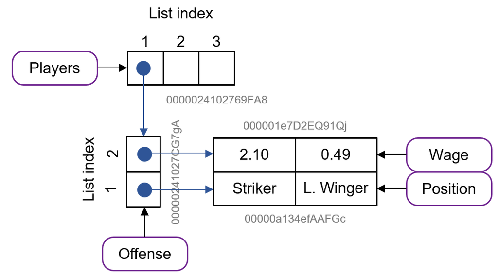

Each element of the list is named and can be further accessed by that name. Names of the grocery types are provided as formal parameters to the `list()` function using the `=` operator. To retrieve the content of a specific element, you can use the dollar sign (`$`) operator followed by the name you wish to access.

```r
Players$Offense
```

```
##      Position Wage
## 1     Striker 2.10
## 2 Left Winger 0.49
```

Lists are created using the `list()` function, but can also created lists by coercing. To linearize a list use the `unlist()` function.

**Task 1:** Before running the code, come up with an idea how would the results differ of the following computations:

```r
List1 <- list(list(1, 2), c(3, 4))
List2 <- c(list(1, 2), c(3, 4))
```

**Task 2:** Think now about similarities and differences between a `list()` and an atomic vector coined by `c()`. What do they have in common and what are their differences? Name use cases where `c()` is desired and `list()` won’t do the job.

**Task 3:** You can turn a list into an atomic vector with `unlist()`. The rules for the resulting type are complex, not well documented, and not always equivalent to what you’d get with `c()`. Unlist `List1` and `List2` and see if they returned the same structure.

**Task 4:** A list can contain other lists. This makes them fundamentally different from atomic vectors. What structure would you expect from the following code? Use `str()`, or `lobstr::ast()` to find out.

```r
List3 <- list(list(list(1)))
```

### Data Frames

The most important application of a list is a **data frame**. A data frame is a list of column-bind list of vectors with attributes. In contrast to a regular **list**, a data frame has an additional constraint: the length of each of its vectors must be the same. This gives data frames their rectangular structure and explains why they share the properties of both matrices and lists.

Let’s take the first line of previous code and visualize how it is implemented.

```r
Offense <- data.frame(Position = c(‘Striker', ‘Left Winger’), Wage = c(2.1, 0.49))
```

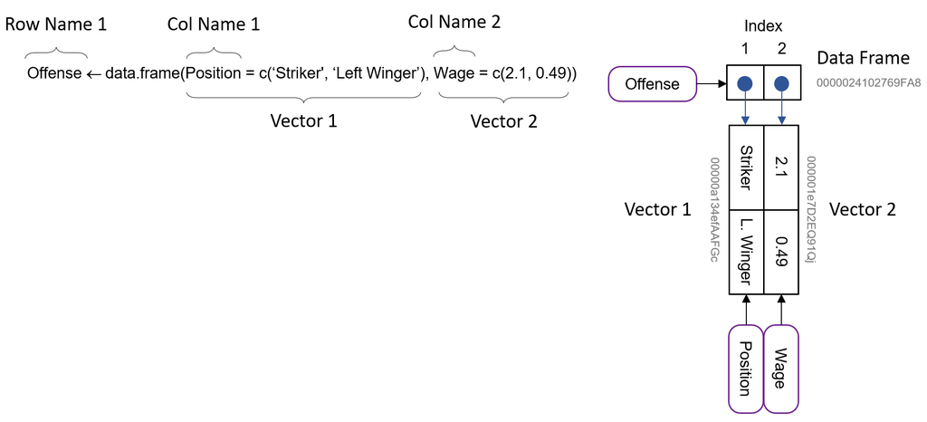

- A flat list has names of its elements accessible with `names()`.
- A data frame has `rownames()`, `colnames()`. When `names()` are used on a data frame, column names are returned.
- Number of rows and columns of a data frame can be returned with `nrow()` and `ncol()`. `dim()` returns a vector containing both values.

```r
names(Players) # Returns names of every element in groceries.
```

```
## [1] "Offense"     "Midfielders" "Defense"
```

```r
colnames(Players[[1]]) # Returns column names of the first table in groceries.
```

```
## [1] "Position" "Wage"
```

Notice that **data frames are column-bound lists**, so copy-on-modify has important consequences when you modify a data frame. If you modify a column, the others will still point to their original references. However, if you modify a row, every column will be modified. This will have severe memory implications if your data frame is large.

Data frames are one of the biggest and most important ideas in R. However, in the over 20 years since their creation, the ways that people use R have changed, and some of the design decisions that made sense at the time data frames were created now cause frustration.

This frustration lead to the creation of the tibble (provided by the Tibble package, which is part of Tidyverse) a modern re-imagining of the data frame.

## Subsetting Operators

The square bracket operator `[` is used to modify list the same way as it is used to modify atomic vectors. However, there are two other subsetting operators that are applicable on lists and data frames. The double bracket operator `[[` is used for extracting single items from a list, whilst the dollar sign operator `x$y` is a useful shorthand for `x[["y"]]`.

### The Double Bracket Operator `[[`

The double bracket operator `[[` is most important when working with lists because subsetting a list with `[` always returns a smaller list. Given that `Players` is a list, any expression you feed to `[` returns a list. The list can contain one or more data frames, or none. You can always view the structure of an object you wish to subset with `View()`.

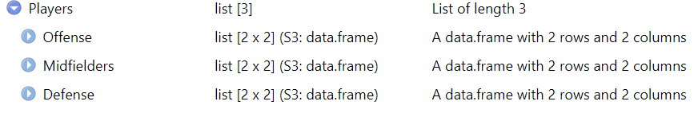

Let’s use this metaphor on `Players` data.

```r
class(Players[1])
```

```
## [1] "list"
```

```r
class(Players[[1]])
```

```
## [1] "data.frame"
```

### The $ Sign Operator

You should be using `[[` when converting a specific column or a row from a data frame to an atomic vector. Doing so reinforces the expectation that you are getting individual values.

An alternative way of doing the same thing is using the dollar sign operator `$`, which is a shorthand operator: `x$y` is roughly equivalent to `x[["y"]]`. It’s often used to access variables in a data frame, which has named columns.

The one important difference between `$` and `[[]]` is that `$` does (left-to-right) partial matching.

```r
Players$Off # Off is partially matched to Offense, which is returned
```

```
##      Position Wage
## 1     Striker 2.10
## 2 Left Winger 0.49
```

```r
Players$Offense
```

```
##      Position Wage
## 1     Striker 2.10
## 2 Left Winger 0.49
```

### Character Subsetting

The dollar sign operator `$` is commonly used for data frame manipulations, thus complementing integer and logical subsetting. For example, you might use `$` sign operator for:

### Simplifying and Preserving Subsetting

Having discussed the difference between `[` and `[[`, it is important to summarize the distinction between simplifying and preserving subsetting. **Simplifying subsetting** returns the simplest possible data structure that can represent the output, and is useful interactively because it usually gives you what you need for ML.

**Preserving subsetting** by contrast, keeps the structure of the output the same as the input, and is generally better for programming because the result will always be the same type.

Omitting `drop = FALSE` when subsetting matrices and data frames is one of the most common sources of programming errors. It will work for your test cases, but then someone will pass in a single column data frame and it will fail in an unexpected and unclear way.

[output not shown]